# Basic Statistical Descriptions of Data

## Customer bank data set

```r
bank <- read.csv('Datasets/customer_bank_data.csv',header = TRUE)
head(bank)
```

```
##   CUSTOMERID AGE      EDUCATION YEARSEMPLOYED INCOME CARDDEBT OTHERDEBT
## 1          1  41 UNDER GRADUATE             6     19    0.124     1.073
## 2          2  47         SCHOOL            26    100    4.582     8.218
## 3          3  33 UNDER GRADUATE            10     57    6.111     5.802
## 4          4  29 UNDER GRADUATE             4     19    0.681     0.516
## 5          5  47         SCHOOL            31    253    9.308     8.908
## 6          6  40         SCHOOL            23     81    0.998     7.831
##   DEFAULTED ADDRESS
## 1         0  NBA001
## 2         0  NBA021
## 3         1  NBA013
## 4         0  NBA009
## 5         0  NBA008
## 6    $null$  NBA016
```

The most common and effective numeric measure of the “center” of a set of data is the (arithmetic) mean.

```r
mean(bank$INCOME)
```

```
## [1] 46.67529
```

For skewed (asymmetric) data, a better measure of the center of data is the median, which is the middle value in a set of ordered data values.

```r
median(bank$INCOME)
```

```
## [1] 35
```

The 4-quantiles are the three data points that split the data distribution into four equal parts; each part represents one-fourth of the data distribution. They are more commonly referred to as quartiles.

```r
quantile(bank$INCOME)
```

```
##     0%    25%    50%    75%   100%
##  13.00  24.00  35.00  55.75 446.00
```

The 100-quantiles are more commonly referred to aspercentiles; they divide the data distribution into 100 equal-sized consecutive sets.

```r
quantile(bank$INCOME,probs = seq(0.12,0.2,by=0.01))
```

```
## 12% 13% 14% 15% 16% 17% 18% 19% 20%
##  20  20  21  21  21  21  22  22  22
```

The distance between the first and third quartiles is a simple measure of spread that gives the range covered by the middle half of the data. This distance is called the interquartile range (IQR) and is defined as  
IQR = Q3 − Q1

```r
IQR(bank$INCOME)
```

```
## [1] 31.75
```

## Five-Number Summary, Boxplots, and Outliers

The **five-number** summary of a distribution consists of the median (Q2), the quartiles Q1 and Q3, and the smallest and largest individual observations, written in the order of Minimum, Q1, Median, Q3, Maximum.  
**Boxplots** are a popular way of visualizing a distribution. When dealing with a moderate number of observations, it is worthwhile to plot potential outliers individually. To do this in a boxplot, the whiskers are extended to the extreme low and high observations only if these values are less than 1.5× IQR beyond the quartiles.

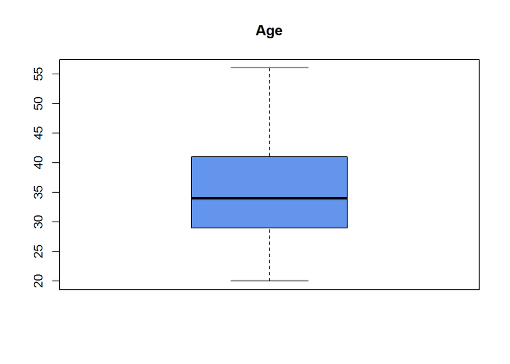

```r
boxplot(bank$AGE,col = 'cornflowerblue',main='Age')
```

Boxplots can be used in the comparisons of several sets of compatible data.

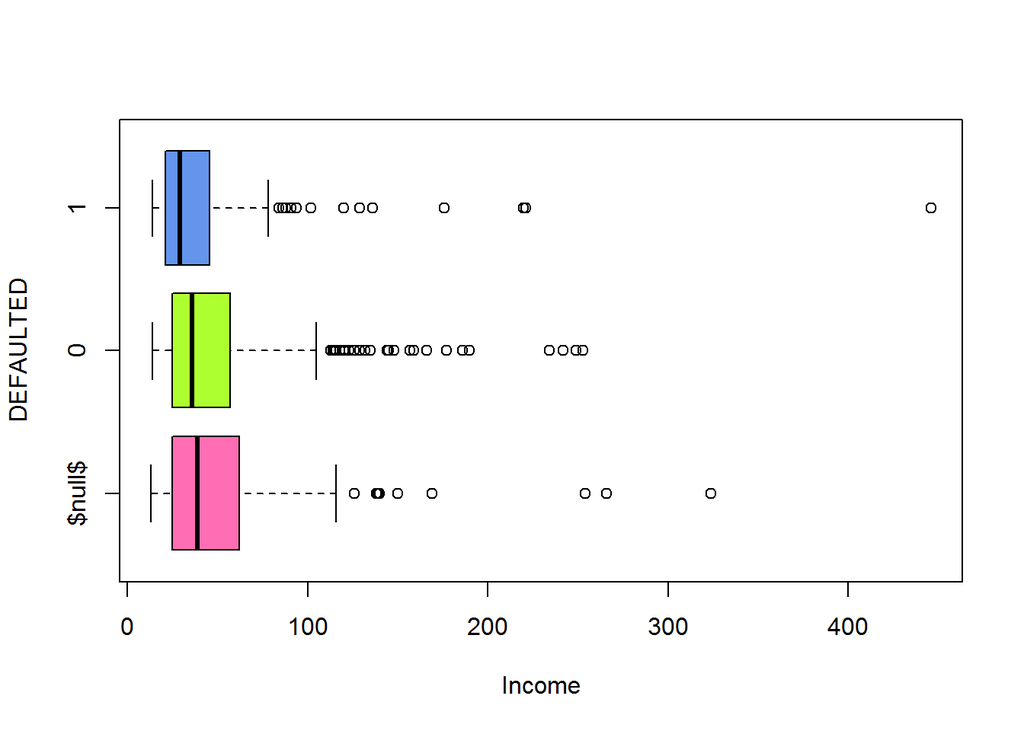

```r
color <- c('hotpink1','greenyellow','cornflowerblue')
boxplot(bank$INCOME~bank$DEFAULTED,horizontal=T,col = color,xlab='Income',ylab='DEFAULTED')
```

## Variance and Standard Deviation

```r
var(bank$INCOME)
```

```
## [1] 1485.567
```

```r
sd(bank$INCOME)
```

```
## [1] 38.54305
```

## Shannon Entropy

The entropy quantifies the expected value of the information contained in a vector.

```r
library(DescTools)
Entropy(table(bank$DEFAULTED))
```

```
## [1] 1.354914
```

## Quantile Plot

A quantile–quantile plot, or q-q plot, graphs the quantiles of one univariate distribution against the corresponding quantiles of another. It is a powerful visualization tool in that it allows the user to view whether there is a shift in going from one distribution to another.

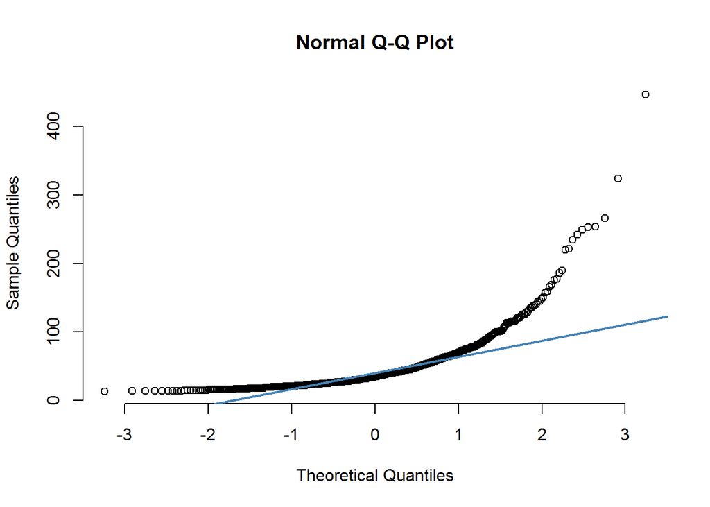

```r
qqnorm(bank$INCOME, pch = 1, frame = FALSE)
qqline(bank$INCOME, col = "steelblue", lwd = 2)
```

## Histograms

If X is nominal, the resulting graph is more commonly known as a bar chart.

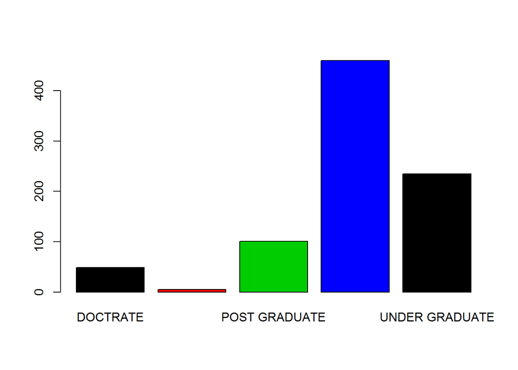

```r
barplot(table(bank$EDUCATION),col=1:4)
```

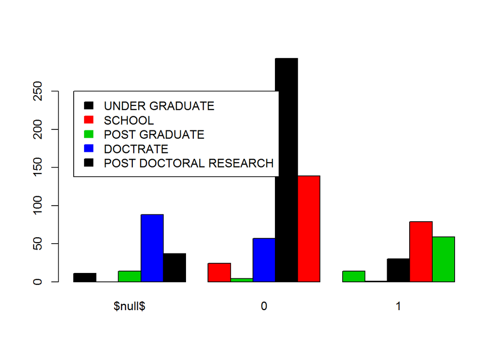

```r
barplot(table(bank$EDUCATION,bank$DEFAULTED),col=1:4,beside = TRUE)
legend(1,250,leg=unique(bank$EDUCATION),fill=1:4,border = 1:4)
```

If X is numeric, the term histogram is preferred. The subranges, referred to as buckets or bins, are disjoint subsets of the data distribution for X.

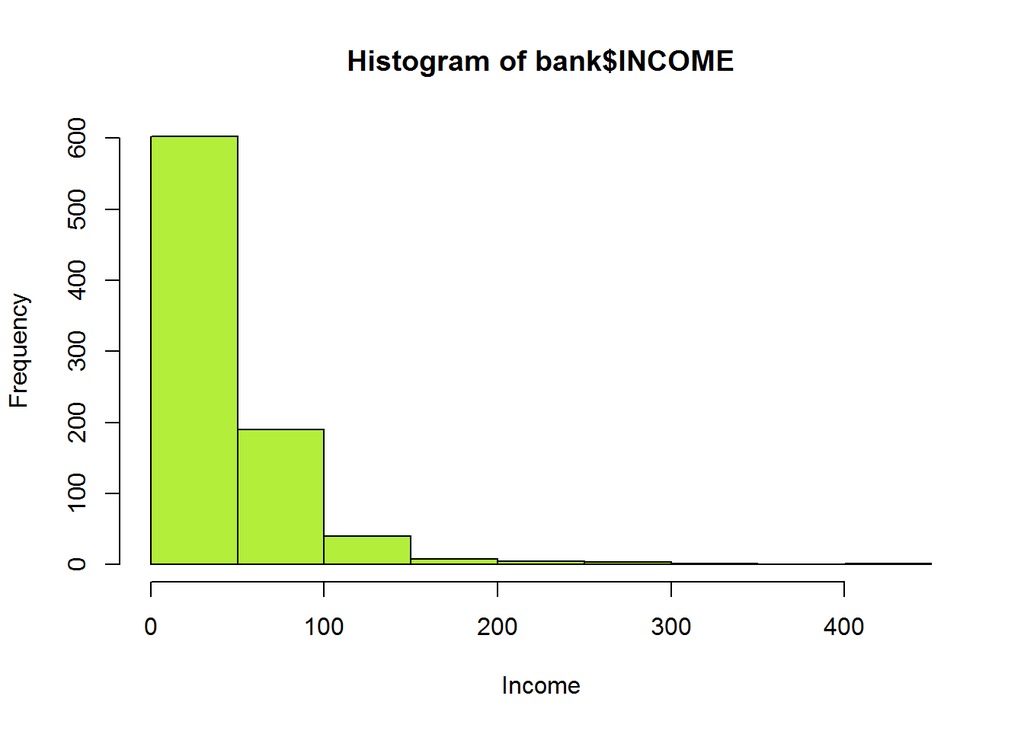

```r
hist(bank$INCOME,col = 'olivedrab2',xlab = 'Income')
```

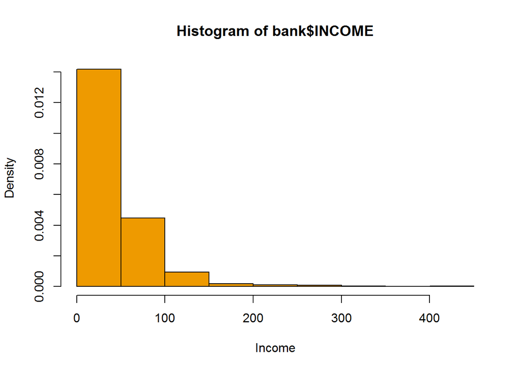

```r
hist(bank$INCOME,col = 'orange2',xlab = 'Income',probability = TRUE)
```

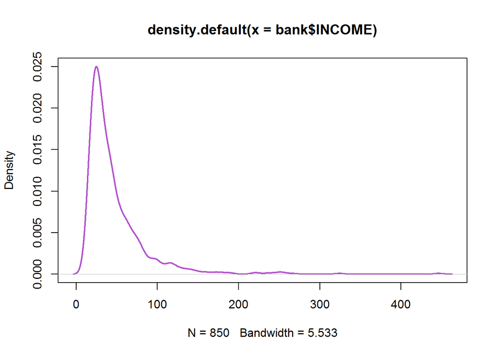

```r
plot(density(bank$INCOME),add=TRUE,col='mediumorchid3',lwd=2)
```

## Scatter Plots

The most effective graphical methods for determining if there appears to be a relationship, pattern, or trend between two numeric attributes.

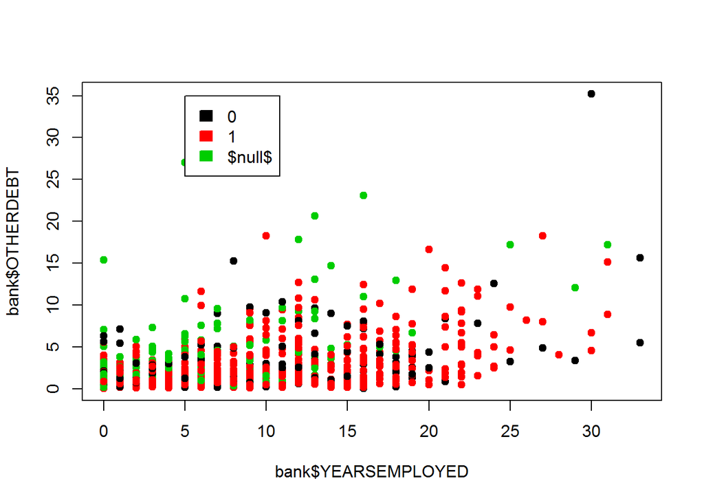

```r
plot(bank$YEARSEMPLOYED, bank$OTHERDEBT,col=bank$DEFAULTED,pch=19)
legend(5,35,leg=unique(bank$DEFAULTED),fill=1:3,border = 1:3)
```

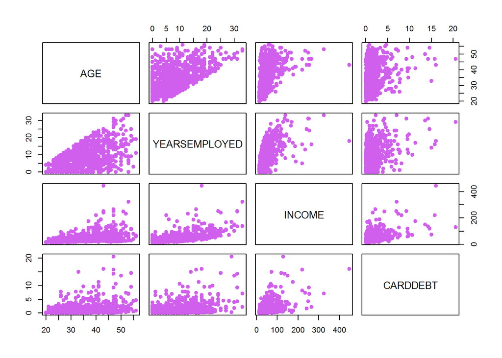

```r
pairs(bank[,c(2,4,5,6)],pch=19,col='mediumorchid2')
```

## Bubble Plots

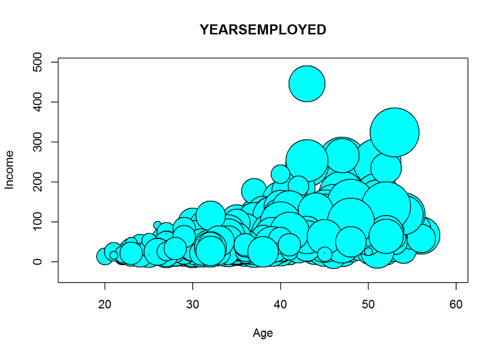

```r
radius <- sqrt( bank$YEARSEMPLOYED/ pi )
symbols(bank$AGE, bank$INCOME ,circles=radius,
        inches=0.35, bg="cyan", xlab="Age", ylab="Income",main='YEARSEMPLOYED')
```

## Data Correlation

```r
cor(bank$YEARSEMPLOYED, bank$OTHERDEBT)
```

```
## [1] 0.4144295
```

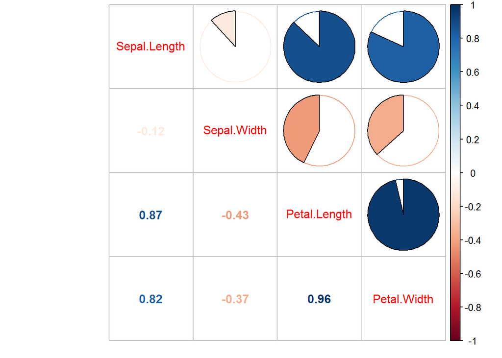

```r
library(corrplot)
C=cor(iris[,-5])
corrplot.mixed(C, lower="number", upper="pie")
```